# Risk Factor Analysis

## Outcome Variable

**Outcome Variable:** y_rate_len

## Predictor Variables

**Intervention Variable:** birthlen

**Adjustment Set:**

- arm
- sex
- W_mage
- meducyrs
- feducyrs
- W_mhtcm
- vagbrth
- single
- W_nrooms
- brthmon
- W_parity
- impsan
- delta_W_mage
- delta_meducyrs
- delta_feducyrs
- delta_W_mhtcm
- delta_vagbrth
- delta_single
- delta_W_nrooms
- delta_brthmon
- delta_W_parity
- delta_impsan

## Stratifying Variables

The analysis was stratified on these variable(s):

- agecat
- studyid
- country

## Data Summary

| agecat | studyid | country | birthlen | n_cell | n |
| --- | --- | --- | --- | --- | --- |
| 0-3 months | ki0047075b-MAL-ED | BANGLADESH | >=0 | 37 | 238 |
| 0-3 months | ki0047075b-MAL-ED | BANGLADESH | <-3 | 6 | 238 |
| 0-3 months | ki0047075b-MAL-ED | BANGLADESH | [-3–2) | 34 | 238 |
| 0-3 months | ki0047075b-MAL-ED | BANGLADESH | [-2–1) | 77 | 238 |
| 0-3 months | ki0047075b-MAL-ED | BANGLADESH | [-1-0) | 84 | 238 |
| 0-3 months | ki1017093-NIH-Birth | BANGLADESH | >=0 | 5 | 23 |
| 0-3 months | ki1017093-NIH-Birth | BANGLADESH | [-3–2) | 1 | 23 |
| 0-3 months | ki1017093-NIH-Birth | BANGLADESH | [-2–1) | 8 | 23 |
| 0-3 months | ki1017093-NIH-Birth | BANGLADESH | [-1-0) | 9 | 23 |
| 0-3 months | ki1017093b-PROVIDE | BANGLADESH | >=0 | 199 | 634 |
| 0-3 months | ki1017093b-PROVIDE | BANGLADESH | <-3 | 1 | 634 |
| 0-3 months | ki1017093b-PROVIDE | BANGLADESH | [-3–2) | 21 | 634 |
| 0-3 months | ki1017093b-PROVIDE | BANGLADESH | [-2–1) | 160 | 634 |
| 0-3 months | ki1017093b-PROVIDE | BANGLADESH | [-1-0) | 253 | 634 |
| 0-3 months | ki1017093c-NIH-Crypto | BANGLADESH | >=0 | 209 | 720 |
| 0-3 months | ki1017093c-NIH-Crypto | BANGLADESH | <-3 | 5 | 720 |
| 0-3 months | ki1017093c-NIH-Crypto | BANGLADESH | [-3–2) | 46 | 720 |
| 0-3 months | ki1017093c-NIH-Crypto | BANGLADESH | [-2–1) | 177 | 720 |
| 0-3 months | ki1017093c-NIH-Crypto | BANGLADESH | [-1-0) | 283 | 720 |
| 0-3 months | kiGH5241-JiVitA-3 | BANGLADESH | >=0 | 1865 | 20045 |
| 0-3 months | kiGH5241-JiVitA-3 | BANGLADESH | <-3 | 1910 | 20045 |
| 0-3 months | kiGH5241-JiVitA-3 | BANGLADESH | [-3–2) | 4082 | 20045 |
| 0-3 months | kiGH5241-JiVitA-3 | BANGLADESH | [-2–1) | 6946 | 20045 |
| 0-3 months | kiGH5241-JiVitA-3 | BANGLADESH | [-1-0) | 5242 | 20045 |
| 0-3 months | kiGH5241-JiVitA-4 | BANGLADESH | >=0 | 216 | 1807 |
| 0-3 months | kiGH5241-JiVitA-4 | BANGLADESH | <-3 | 130 | 1807 |
| 0-3 months | kiGH5241-JiVitA-4 | BANGLADESH | [-3–2) | 326 | 1807 |
| 0-3 months | kiGH5241-JiVitA-4 | BANGLADESH | [-2–1) | 609 | 1807 |
| 0-3 months | kiGH5241-JiVitA-4 | BANGLADESH | [-1-0) | 526 | 1807 |
| 0-3 months | ki1119695-PROBIT | BELARUS | >=0 | 11610 | 12745 |

[output cut: 408 more lines]

The following strata were considered:

- agecat: 0-3 months, studyid: ki0047075b-MAL-ED, country: BANGLADESH
- agecat: 0-3 months, studyid: ki0047075b-MAL-ED, country: BRAZIL
- agecat: 0-3 months, studyid: ki0047075b-MAL-ED, country: INDIA
- agecat: 0-3 months, studyid: ki0047075b-MAL-ED, country: NEPAL
- agecat: 0-3 months, studyid: ki0047075b-MAL-ED, country: PERU
- agecat: 0-3 months, studyid: ki0047075b-MAL-ED, country: SOUTH AFRICA
- agecat: 0-3 months, studyid: ki0047075b-MAL-ED, country: TANZANIA, UNITED REPUBLIC OF
- agecat: 0-3 months, studyid: ki1000108-CMC-V-BCS-2002, country: INDIA
- agecat: 0-3 months, studyid: ki1000108-IRC, country: INDIA
- agecat: 0-3 months, studyid: ki1000109-EE, country: PAKISTAN
- agecat: 0-3 months, studyid: ki1000109-ResPak, country: PAKISTAN
- agecat: 0-3 months, studyid: ki1000304b-SAS-CompFeed, country: INDIA
- agecat: 0-3 months, studyid: ki1017093-NIH-Birth, country: BANGLADESH
- agecat: 0-3 months, studyid: ki1017093b-PROVIDE, country: BANGLADESH
- agecat: 0-3 months, studyid: ki1017093c-NIH-Crypto, country: BANGLADESH
- agecat: 0-3 months, studyid: ki1101329-Keneba, country: GAMBIA
- agecat: 0-3 months, studyid: ki1114097-CMIN, country: BRAZIL
- agecat: 0-3 months, studyid: ki1114097-CMIN, country: PERU
- agecat: 0-3 months, studyid: ki1114097-CONTENT, country: PERU
- agecat: 0-3 months, studyid: ki1119695-PROBIT, country: BELARUS
- agecat: 0-3 months, studyid: ki1126311-ZVITAMBO, country: ZIMBABWE
- agecat: 0-3 months, studyid: ki1135781-COHORTS, country: GUATEMALA
- agecat: 0-3 months, studyid: ki1135781-COHORTS, country: INDIA
- agecat: 0-3 months, studyid: kiGH5241-JiVitA-3, country: BANGLADESH
- agecat: 0-3 months, studyid: kiGH5241-JiVitA-4, country: BANGLADESH
- agecat: 12-24 months, studyid: ki0047075b-MAL-ED, country: BANGLADESH
- agecat: 12-24 months, studyid: ki0047075b-MAL-ED, country: BRAZIL
- agecat: 12-24 months, studyid: ki0047075b-MAL-ED, country: INDIA
- agecat: 12-24 months, studyid: ki0047075b-MAL-ED, country: NEPAL
- agecat: 12-24 months, studyid: ki0047075b-MAL-ED, country: PERU
- agecat: 12-24 months, studyid: ki0047075b-MAL-ED, country: SOUTH AFRICA
- agecat: 12-24 months, studyid: ki0047075b-MAL-ED, country: TANZANIA, UNITED REPUBLIC OF
- agecat: 12-24 months, studyid: ki1000108-CMC-V-BCS-2002, country: INDIA
- agecat: 12-24 months, studyid: ki1000108-IRC, country: INDIA
- agecat: 12-24 months, studyid: ki1017093-NIH-Birth, country: BANGLADESH
- agecat: 12-24 months, studyid: ki1017093b-PROVIDE, country: BANGLADESH
- agecat: 12-24 months, studyid: ki1017093c-NIH-Crypto, country: BANGLADESH
- agecat: 12-24 months, studyid: ki1101329-Keneba, country: GAMBIA
- agecat: 12-24 months, studyid: ki1114097-CMIN, country: PERU
- agecat: 12-24 months, studyid: ki1119695-PROBIT, country: BELARUS
- agecat: 12-24 months, studyid: ki1126311-ZVITAMBO, country: ZIMBABWE
- agecat: 12-24 months, studyid: ki1135781-COHORTS, country: GUATEMALA
- agecat: 12-24 months, studyid: ki1135781-COHORTS, country: INDIA
- agecat: 12-24 months, studyid: ki1135781-COHORTS, country: PHILIPPINES
- agecat: 12-24 months, studyid: kiGH5241-JiVitA-3, country: BANGLADESH
- agecat: 12-24 months, studyid: kiGH5241-JiVitA-4, country: BANGLADESH
- agecat: 3-6 months, studyid: ki0047075b-MAL-ED, country: BANGLADESH
- agecat: 3-6 months, studyid: ki0047075b-MAL-ED, country: BRAZIL
- agecat: 3-6 months, studyid: ki0047075b-MAL-ED, country: INDIA
- agecat: 3-6 months, studyid: ki0047075b-MAL-ED, country: NEPAL
- agecat: 3-6 months, studyid: ki0047075b-MAL-ED, country: PERU
- agecat: 3-6 months, studyid: ki0047075b-MAL-ED, country: SOUTH AFRICA
- agecat: 3-6 months, studyid: ki0047075b-MAL-ED, country: TANZANIA, UNITED REPUBLIC OF
- agecat: 3-6 months, studyid: ki1000108-CMC-V-BCS-2002, country: INDIA
- agecat: 3-6 months, studyid: ki1000108-IRC, country: INDIA
- agecat: 3-6 months, studyid: ki1000109-EE, country: PAKISTAN
- agecat: 3-6 months, studyid: ki1000109-ResPak, country: PAKISTAN
- agecat: 3-6 months, studyid: ki1000304b-SAS-CompFeed, country: INDIA
- agecat: 3-6 months, studyid: ki1017093-NIH-Birth, country: BANGLADESH
- agecat: 3-6 months, studyid: ki1017093b-PROVIDE, country: BANGLADESH
- agecat: 3-6 months, studyid: ki1017093c-NIH-Crypto, country: BANGLADESH
- agecat: 3-6 months, studyid: ki1101329-Keneba, country: GAMBIA
- agecat: 3-6 months, studyid: ki1114097-CMIN, country: BRAZIL
- agecat: 3-6 months, studyid: ki1114097-CMIN, country: PERU
- agecat: 3-6 months, studyid: ki1114097-CONTENT, country: PERU
- agecat: 3-6 months, studyid: ki1119695-PROBIT, country: BELARUS
- agecat: 3-6 months, studyid: ki1126311-ZVITAMBO, country: ZIMBABWE
- agecat: 3-6 months, studyid: ki1135781-COHORTS, country: GUATEMALA
- agecat: 3-6 months, studyid: ki1135781-COHORTS, country: INDIA
- agecat: 3-6 months, studyid: kiGH5241-JiVitA-3, country: BANGLADESH
- agecat: 3-6 months, studyid: kiGH5241-JiVitA-4, country: BANGLADESH
- agecat: 6-12 months, studyid: ki0047075b-MAL-ED, country: BANGLADESH
- agecat: 6-12 months, studyid: ki0047075b-MAL-ED, country: BRAZIL
- agecat: 6-12 months, studyid: ki0047075b-MAL-ED, country: INDIA
- agecat: 6-12 months, studyid: ki0047075b-MAL-ED, country: NEPAL
- agecat: 6-12 months, studyid: ki0047075b-MAL-ED, country: PERU
- agecat: 6-12 months, studyid: ki0047075b-MAL-ED, country: SOUTH AFRICA
- agecat: 6-12 months, studyid: ki0047075b-MAL-ED, country: TANZANIA, UNITED REPUBLIC OF
- agecat: 6-12 months, studyid: ki1000108-CMC-V-BCS-2002, country: INDIA
- agecat: 6-12 months, studyid: ki1000108-IRC, country: INDIA
- agecat: 6-12 months, studyid: ki1000109-ResPak, country: PAKISTAN
- agecat: 6-12 months, studyid: ki1000304b-SAS-CompFeed, country: INDIA
- agecat: 6-12 months, studyid: ki1017093-NIH-Birth, country: BANGLADESH
- agecat: 6-12 months, studyid: ki1017093b-PROVIDE, country: BANGLADESH
- agecat: 6-12 months, studyid: ki1017093c-NIH-Crypto, country: BANGLADESH
- agecat: 6-12 months, studyid: ki1101329-Keneba, country: GAMBIA
- agecat: 6-12 months, studyid: ki1114097-CMIN, country: BRAZIL
- agecat: 6-12 months, studyid: ki1114097-CMIN, country: PERU
- agecat: 6-12 months, studyid: ki1114097-CONTENT, country: PERU
- agecat: 6-12 months, studyid: ki1119695-PROBIT, country: BELARUS
- agecat: 6-12 months, studyid: ki1126311-ZVITAMBO, country: ZIMBABWE
- agecat: 6-12 months, studyid: ki1135781-COHORTS, country: GUATEMALA
- agecat: 6-12 months, studyid: ki1135781-COHORTS, country: INDIA
- agecat: 6-12 months, studyid: ki1135781-COHORTS, country: PHILIPPINES
- agecat: 6-12 months, studyid: kiGH5241-JiVitA-3, country: BANGLADESH
- agecat: 6-12 months, studyid: kiGH5241-JiVitA-4, country: BANGLADESH

### Dropped Strata

Some strata were dropped due to rare outcomes:

- agecat: 0-3 months, studyid: ki1017093-NIH-Birth, country: BANGLADESH
- agecat: 0-3 months, studyid: ki1017093b-PROVIDE, country: BANGLADESH
- agecat: 0-3 months, studyid: ki1114097-CMIN, country: BRAZIL
- agecat: 0-3 months, studyid: ki1000108-CMC-V-BCS-2002, country: INDIA
- agecat: 0-3 months, studyid: ki1000109-EE, country: PAKISTAN
- agecat: 0-3 months, studyid: ki1000109-ResPak, country: PAKISTAN
- agecat: 0-3 months, studyid: ki1114097-CONTENT, country: PERU
- agecat: 0-3 months, studyid: ki0047075b-MAL-ED, country: SOUTH AFRICA
- agecat: 0-3 months, studyid: ki0047075b-MAL-ED, country: TANZANIA, UNITED REPUBLIC OF
- agecat: 3-6 months, studyid: ki1017093-NIH-Birth, country: BANGLADESH
- agecat: 3-6 months, studyid: ki1017093b-PROVIDE, country: BANGLADESH
- agecat: 3-6 months, studyid: ki1114097-CMIN, country: BRAZIL
- agecat: 3-6 months, studyid: ki1000108-CMC-V-BCS-2002, country: INDIA
- agecat: 3-6 months, studyid: ki1000109-EE, country: PAKISTAN
- agecat: 3-6 months, studyid: ki1000109-ResPak, country: PAKISTAN
- agecat: 3-6 months, studyid: ki1114097-CONTENT, country: PERU
- agecat: 3-6 months, studyid: ki0047075b-MAL-ED, country: SOUTH AFRICA
- agecat: 3-6 months, studyid: ki0047075b-MAL-ED, country: TANZANIA, UNITED REPUBLIC OF
- agecat: 6-12 months, studyid: ki1017093-NIH-Birth, country: BANGLADESH
- agecat: 6-12 months, studyid: ki1017093b-PROVIDE, country: BANGLADESH
- agecat: 6-12 months, studyid: ki1119695-PROBIT, country: BELARUS
- agecat: 6-12 months, studyid: ki1114097-CMIN, country: BRAZIL
- agecat: 6-12 months, studyid: ki0047075b-MAL-ED, country: INDIA
- agecat: 6-12 months, studyid: ki1000108-CMC-V-BCS-2002, country: INDIA
- agecat: 6-12 months, studyid: ki1000109-ResPak, country: PAKISTAN
- agecat: 6-12 months, studyid: ki1114097-CONTENT, country: PERU
- agecat: 6-12 months, studyid: ki0047075b-MAL-ED, country: SOUTH AFRICA
- agecat: 12-24 months, studyid: ki1017093-NIH-Birth, country: BANGLADESH
- agecat: 12-24 months, studyid: ki1017093b-PROVIDE, country: BANGLADESH
- agecat: 12-24 months, studyid: ki1119695-PROBIT, country: BELARUS
- agecat: 12-24 months, studyid: ki1000108-CMC-V-BCS-2002, country: INDIA
- agecat: 12-24 months, studyid: ki0047075b-MAL-ED, country: PERU
- agecat: 12-24 months, studyid: ki1114097-CMIN, country: PERU
- agecat: 12-24 months, studyid: ki0047075b-MAL-ED, country: SOUTH AFRICA

## Methods Detail

We’re interested in the causal parameters $E[Y_a]$ for all values of $a \in \mathcal{A}$. These parameters represent the mean outcome if, possibly contrary to fact, we intervened to set all units to have $A=a$. Under the randomization and positivity assumptions, these are identified by the statistical parameters $\psi_a=E_W[E_{Y|A,W}(Y|A=a,W)]$. In addition, we’re interested in the mean of $Y$, $E[Y]$ under no intervention (the observed mean). We will estimate these parameters by using SuperLearner to fit the relevant likelihood factors – $E_{Y|A,W}(Y|A=a,W)$ and $p(A=a|W)$, and then updating our likelihood fit using a joint TMLE.

For unadjusted analyses ($W=\{\}$), initial likelihoods were estimated using Lrnr_glm to estimate the simple $E(Y|A)$ and Lrnr_mean to estimate $p(A)$. For adjusted analyses, a small library containing Lrnr_glmnet, Lrnr_xgboost, and Lrnr_mean was used.

Having estimated these parameters, we will then use the delta method to estimate relative risks and attributable risks relative to a prespecified baseline level of $A$.

[output not shown]

[output not shown]

[output not shown]

# Results Detail

## Results Plots

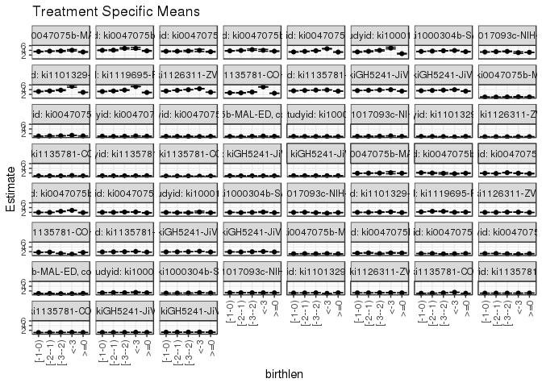

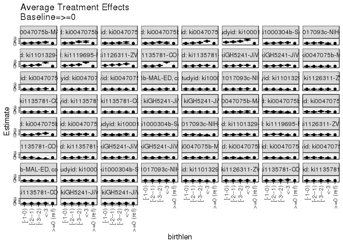

## Results Table

### Parameter: TSM

| agecat | studyid | country | intervention_level | baseline_level | estimate | ci_lower | ci_upper |
| --- | --- | --- | --- | --- | --- | --- | --- |
| 0-3 months | ki0047075b-MAL-ED | BANGLADESH | >=0 | NA | 3.3104863 | 3.1557376 | 3.4652350 |
| 0-3 months | ki0047075b-MAL-ED | BANGLADESH | <-3 | NA | 4.0379616 | 3.7416286 | 4.3342945 |
| 0-3 months | ki0047075b-MAL-ED | BANGLADESH | [-3–2) | NA | 3.7377851 | 3.5313723 | 3.9441980 |
| 0-3 months | ki0047075b-MAL-ED | BANGLADESH | [-2–1) | NA | 3.6531669 | 3.5623842 | 3.7439495 |
| 0-3 months | ki0047075b-MAL-ED | BANGLADESH | [-1-0) | NA | 3.4792643 | 3.3814155 | 3.5771131 |
| 0-3 months | ki0047075b-MAL-ED | BRAZIL | >=0 | NA | 3.7748709 | 3.6069329 | 3.9428088 |
| 0-3 months | ki0047075b-MAL-ED | BRAZIL | <-3 | NA | 4.8268550 | 4.3908291 | 5.2628810 |
| 0-3 months | ki0047075b-MAL-ED | BRAZIL | [-3–2) | NA | 4.8241765 | 4.5254381 | 5.1229149 |
| 0-3 months | ki0047075b-MAL-ED | BRAZIL | [-2–1) | NA | 4.0804880 | 3.8487315 | 4.3122445 |
| 0-3 months | ki0047075b-MAL-ED | BRAZIL | [-1-0) | NA | 4.0160492 | 3.8803399 | 4.1517585 |
| 0-3 months | ki0047075b-MAL-ED | INDIA | >=0 | NA | 3.4063562 | 3.2590844 | 3.5536281 |
| 0-3 months | ki0047075b-MAL-ED | INDIA | <-3 | NA | 3.9668801 | 3.4859337 | 4.4478266 |
| 0-3 months | ki0047075b-MAL-ED | INDIA | [-3–2) | NA | 3.7386277 | 3.4765268 | 4.0007286 |
| 0-3 months | ki0047075b-MAL-ED | INDIA | [-2–1) | NA | 3.6083849 | 3.4903074 | 3.7264624 |
| 0-3 months | ki0047075b-MAL-ED | INDIA | [-1-0) | NA | 3.5848319 | 3.4374654 | 3.7321984 |
| 0-3 months | ki0047075b-MAL-ED | NEPAL | >=0 | NA | 3.6380516 | 3.5099215 | 3.7661817 |
| 0-3 months | ki0047075b-MAL-ED | NEPAL | <-3 | NA | 4.0218312 | 3.6274821 | 4.4161804 |
| 0-3 months | ki0047075b-MAL-ED | NEPAL | [-3–2) | NA | 4.3001082 | 3.9883703 | 4.6118462 |
| 0-3 months | ki0047075b-MAL-ED | NEPAL | [-2–1) | NA | 3.9402133 | 3.8071981 | 4.0732285 |
| 0-3 months | ki0047075b-MAL-ED | NEPAL | [-1-0) | NA | 3.7766433 | 3.6624902 | 3.8907965 |
| 0-3 months | ki0047075b-MAL-ED | PERU | >=0 | NA | 3.2699111 | 3.1552752 | 3.3845471 |
| 0-3 months | ki0047075b-MAL-ED | PERU | <-3 | NA | 4.6852563 | 4.5433705 | 4.8271421 |
| 0-3 months | ki0047075b-MAL-ED | PERU | [-3–2) | NA | 3.8302045 | 3.7123462 | 3.9480629 |
| 0-3 months | ki0047075b-MAL-ED | PERU | [-2–1) | NA | 3.5566852 | 3.4675785 | 3.6457919 |
| 0-3 months | ki0047075b-MAL-ED | PERU | [-1-0) | NA | 3.3221851 | 3.2349653 | 3.4094050 |
| 0-3 months | ki1000108-IRC | INDIA | >=0 | NA | 2.5850846 | 2.4278285 | 2.7423406 |
| 0-3 months | ki1000108-IRC | INDIA | <-3 | NA | 4.9718366 | 4.6025113 | 5.3411619 |
| 0-3 months | ki1000108-IRC | INDIA | [-3–2) | NA | 3.9888444 | 3.7343107 | 4.2433780 |
| 0-3 months | ki1000108-IRC | INDIA | [-2–1) | NA | 3.5879675 | 3.3825100 | 3.7934249 |
| 0-3 months | ki1000108-IRC | INDIA | [-1-0) | NA | 3.3393021 | 3.2008040 | 3.4778002 |

[output cut: 265 more lines]

### Parameter: E(Y)

| agecat | studyid | country | intervention_level | baseline_level | estimate | ci_lower | ci_upper |
| --- | --- | --- | --- | --- | --- | --- | --- |
| 0-3 months | ki0047075b-MAL-ED | BANGLADESH | NA | NA | 3.5603213 | 3.4965371 | 3.6241055 |
| 0-3 months | ki0047075b-MAL-ED | BRAZIL | NA | NA | 4.0509714 | 3.9492443 | 4.1526985 |
| 0-3 months | ki0047075b-MAL-ED | INDIA | NA | NA | 3.5943339 | 3.5152425 | 3.6734253 |
| 0-3 months | ki0047075b-MAL-ED | NEPAL | NA | NA | 3.8294484 | 3.7523124 | 3.9065845 |
| 0-3 months | ki0047075b-MAL-ED | PERU | NA | NA | 3.3131452 | 3.2493248 | 3.3769656 |
| 0-3 months | ki1000108-IRC | INDIA | NA | NA | 3.1729204 | 3.0609523 | 3.2848884 |
| 0-3 months | ki1000304b-SAS-CompFeed | INDIA | NA | NA | 3.6019890 | 3.5739652 | 3.6300127 |
| 0-3 months | ki1017093c-NIH-Crypto | BANGLADESH | NA | NA | 3.3028656 | 3.2646714 | 3.3410598 |
| 0-3 months | ki1101329-Keneba | GAMBIA | NA | NA | 3.1410155 | 3.0942096 | 3.1878215 |
| 0-3 months | ki1119695-PROBIT | BELARUS | NA | NA | 2.8355739 | 2.7218468 | 2.9493011 |
| 0-3 months | ki1126311-ZVITAMBO | ZIMBABWE | NA | NA | 3.3706967 | 3.3498056 | 3.3915878 |
| 0-3 months | ki1135781-COHORTS | GUATEMALA | NA | NA | 2.6117091 | 2.5680119 | 2.6554063 |
| 0-3 months | ki1135781-COHORTS | INDIA | NA | NA | 3.5478988 | 3.5336609 | 3.5621367 |
| 0-3 months | kiGH5241-JiVitA-3 | BANGLADESH | NA | NA | 3.7184443 | 3.7081005 | 3.7287881 |
| 0-3 months | kiGH5241-JiVitA-4 | BANGLADESH | NA | NA | 3.6381167 | 3.6070177 | 3.6692156 |
| 3-6 months | ki0047075b-MAL-ED | BANGLADESH | NA | NA | 1.9333469 | 1.8827032 | 1.9839906 |
| 3-6 months | ki0047075b-MAL-ED | BRAZIL | NA | NA | 2.1370912 | 2.0494394 | 2.2247430 |
| 3-6 months | ki0047075b-MAL-ED | INDIA | NA | NA | 1.8588467 | 1.7931260 | 1.9245674 |
| 3-6 months | ki0047075b-MAL-ED | NEPAL | NA | NA | 1.9537710 | 1.8906776 | 2.0168644 |
| 3-6 months | ki0047075b-MAL-ED | PERU | NA | NA | 2.0203845 | 1.9526963 | 2.0880727 |
| 3-6 months | ki1000108-IRC | INDIA | NA | NA | 1.8979894 | 1.8318964 | 1.9640824 |
| 3-6 months | ki1000304b-SAS-CompFeed | INDIA | NA | NA | 1.9465718 | 1.9002562 | 1.9928873 |
| 3-6 months | ki1017093c-NIH-Crypto | BANGLADESH | NA | NA | 2.0057973 | 1.9693775 | 2.0422170 |
| 3-6 months | ki1101329-Keneba | GAMBIA | NA | NA | 1.9485919 | 1.9035866 | 1.9935972 |
| 3-6 months | ki1119695-PROBIT | BELARUS | NA | NA | 2.0917290 | 2.0505957 | 2.1328624 |
| 3-6 months | ki1126311-ZVITAMBO | ZIMBABWE | NA | NA | 1.9780577 | 1.9580366 | 1.9980788 |
| 3-6 months | ki1135781-COHORTS | GUATEMALA | NA | NA | 1.7456394 | 1.7115844 | 1.7796945 |
| 3-6 months | ki1135781-COHORTS | INDIA | NA | NA | 1.8751782 | 1.8624443 | 1.8879121 |
| 3-6 months | kiGH5241-JiVitA-3 | BANGLADESH | NA | NA | 1.9187845 | 1.9081770 | 1.9293920 |
| 3-6 months | kiGH5241-JiVitA-4 | BANGLADESH | NA | NA | 1.8995744 | 1.8690448 | 1.9301040 |
| 6-12 months | ki0047075b-MAL-ED | BANGLADESH | NA | NA | 1.1145345 | 1.0891836 | 1.1398854 |
| 6-12 months | ki0047075b-MAL-ED | BRAZIL | NA | NA | 1.3893396 | 1.3390346 | 1.4396445 |
| 6-12 months | ki0047075b-MAL-ED | NEPAL | NA | NA | 1.2038122 | 1.1754217 | 1.2322027 |
| 6-12 months | ki0047075b-MAL-ED | PERU | NA | NA | 1.2109599 | 1.1778190 | 1.2441008 |
| 6-12 months | ki0047075b-MAL-ED | TANZANIA, UNITED REPUBLIC OF | NA | NA | 1.0072786 | 0.9485980 | 1.0659592 |
| 6-12 months | ki1000108-IRC | INDIA | NA | NA | 1.2467181 | 1.2162335 | 1.2772028 |
| 6-12 months | ki1000304b-SAS-CompFeed | INDIA | NA | NA | 1.0993205 | 1.0874204 | 1.1112206 |
| 6-12 months | ki1017093c-NIH-Crypto | BANGLADESH | NA | NA | 1.2281313 | 1.2106849 | 1.2455776 |
| 6-12 months | ki1101329-Keneba | GAMBIA | NA | NA | 1.1778182 | 1.1568582 | 1.1987781 |
| 6-12 months | ki1126311-ZVITAMBO | ZIMBABWE | NA | NA | 1.1968156 | 1.1858561 | 1.2077751 |
| 6-12 months | ki1135781-COHORTS | GUATEMALA | NA | NA | 1.0259211 | 1.0057423 | 1.0460999 |
| 6-12 months | ki1135781-COHORTS | INDIA | NA | NA | 1.0985347 | 1.0896671 | 1.1074023 |
| 6-12 months | ki1135781-COHORTS | PHILIPPINES | NA | NA | 1.0669016 | 1.0547084 | 1.0790949 |
| 6-12 months | kiGH5241-JiVitA-3 | BANGLADESH | NA | NA | 1.1067799 | 1.0999217 | 1.1136382 |
| 6-12 months | kiGH5241-JiVitA-4 | BANGLADESH | NA | NA | 1.2035888 | 1.1926725 | 1.2145050 |
| 12-24 months | ki0047075b-MAL-ED | BANGLADESH | NA | NA | 0.8473033 | 0.8311655 | 0.8634412 |
| 12-24 months | ki0047075b-MAL-ED | BRAZIL | NA | NA | 0.9692760 | 0.9358403 | 1.0027117 |
| 12-24 months | ki0047075b-MAL-ED | INDIA | NA | NA | 0.8839536 | 0.8647473 | 0.9031599 |
| 12-24 months | ki0047075b-MAL-ED | NEPAL | NA | NA | 0.8654614 | 0.8481208 | 0.8828019 |
| 12-24 months | ki0047075b-MAL-ED | TANZANIA, UNITED REPUBLIC OF | NA | NA | 0.7794654 | 0.7463664 | 0.8125645 |
| 12-24 months | ki1000108-IRC | INDIA | NA | NA | 0.8307730 | 0.8104424 | 0.8511037 |
| 12-24 months | ki1017093c-NIH-Crypto | BANGLADESH | NA | NA | 0.8755729 | 0.8637860 | 0.8873598 |
| 12-24 months | ki1101329-Keneba | GAMBIA | NA | NA | 0.8470593 | 0.8345607 | 0.8595578 |
| 12-24 months | ki1126311-ZVITAMBO | ZIMBABWE | NA | NA | 0.7095047 | 0.6832130 | 0.7357964 |
| 12-24 months | ki1135781-COHORTS | GUATEMALA | NA | NA | 0.7705085 | 0.7567567 | 0.7842603 |
| 12-24 months | ki1135781-COHORTS | INDIA | NA | NA | 0.8265427 | 0.8213170 | 0.8317684 |
| 12-24 months | ki1135781-COHORTS | PHILIPPINES | NA | NA | 0.7067961 | 0.6994517 | 0.7141404 |
| 12-24 months | kiGH5241-JiVitA-3 | BANGLADESH | NA | NA | 0.7964137 | 0.7910429 | 0.8017845 |
| 12-24 months | kiGH5241-JiVitA-4 | BANGLADESH | NA | NA | 0.8511625 | 0.8452650 | 0.8570599 |

### Parameter: ATE

| agecat | studyid | country | intervention_level | baseline_level | estimate | ci_lower | ci_upper |
| --- | --- | --- | --- | --- | --- | --- | --- |
| 0-3 months | ki0047075b-MAL-ED | BANGLADESH | >=0 | >=0 | 0.0000000 | 0.0000000 | 0.0000000 |
| 0-3 months | ki0047075b-MAL-ED | BANGLADESH | <-3 | >=0 | 0.7274752 | 0.3930318 | 1.0619187 |
| 0-3 months | ki0047075b-MAL-ED | BANGLADESH | [-3–2) | >=0 | 0.4272988 | 0.1705729 | 0.6840247 |
| 0-3 months | ki0047075b-MAL-ED | BANGLADESH | [-2–1) | >=0 | 0.3426805 | 0.1643482 | 0.5210129 |
| 0-3 months | ki0047075b-MAL-ED | BANGLADESH | [-1-0) | >=0 | 0.1687780 | -0.0136148 | 0.3511708 |
| 0-3 months | ki0047075b-MAL-ED | BRAZIL | >=0 | >=0 | 0.0000000 | 0.0000000 | 0.0000000 |
| 0-3 months | ki0047075b-MAL-ED | BRAZIL | <-3 | >=0 | 1.0519841 | 0.5847350 | 1.5192333 |
| 0-3 months | ki0047075b-MAL-ED | BRAZIL | [-3–2) | >=0 | 1.0493056 | 0.7065991 | 1.3920122 |
| 0-3 months | ki0047075b-MAL-ED | BRAZIL | [-2–1) | >=0 | 0.3056171 | 0.0194105 | 0.5918237 |
| 0-3 months | ki0047075b-MAL-ED | BRAZIL | [-1-0) | >=0 | 0.2411784 | 0.0252614 | 0.4570954 |
| 0-3 months | ki0047075b-MAL-ED | INDIA | >=0 | >=0 | 0.0000000 | 0.0000000 | 0.0000000 |
| 0-3 months | ki0047075b-MAL-ED | INDIA | <-3 | >=0 | 0.5605239 | 0.0575344 | 1.0635134 |
| 0-3 months | ki0047075b-MAL-ED | INDIA | [-3–2) | >=0 | 0.3322715 | 0.0316290 | 0.6329140 |
| 0-3 months | ki0047075b-MAL-ED | INDIA | [-2–1) | >=0 | 0.2020287 | 0.0132662 | 0.3907912 |
| 0-3 months | ki0047075b-MAL-ED | INDIA | [-1-0) | >=0 | 0.1784757 | -0.0298651 | 0.3868165 |
| 0-3 months | ki0047075b-MAL-ED | NEPAL | >=0 | >=0 | 0.0000000 | 0.0000000 | 0.0000000 |
| 0-3 months | ki0047075b-MAL-ED | NEPAL | <-3 | >=0 | 0.3837797 | -0.0294503 | 0.7970097 |
| 0-3 months | ki0047075b-MAL-ED | NEPAL | [-3–2) | >=0 | 0.6620566 | 0.3268974 | 0.9972159 |
| 0-3 months | ki0047075b-MAL-ED | NEPAL | [-2–1) | >=0 | 0.3021617 | 0.1209568 | 0.4833666 |
| 0-3 months | ki0047075b-MAL-ED | NEPAL | [-1-0) | >=0 | 0.1385918 | -0.0287964 | 0.3059800 |
| 0-3 months | ki0047075b-MAL-ED | PERU | >=0 | >=0 | 0.0000000 | 0.0000000 | 0.0000000 |
| 0-3 months | ki0047075b-MAL-ED | PERU | <-3 | >=0 | 1.4153452 | 1.2325464 | 1.5981439 |
| 0-3 months | ki0047075b-MAL-ED | PERU | [-3–2) | >=0 | 0.5602934 | 0.3963449 | 0.7242419 |
| 0-3 months | ki0047075b-MAL-ED | PERU | [-2–1) | >=0 | 0.2867740 | 0.1411473 | 0.4324007 |
| 0-3 months | ki0047075b-MAL-ED | PERU | [-1-0) | >=0 | 0.0522740 | -0.0920834 | 0.1966313 |
| 0-3 months | ki1000108-IRC | INDIA | >=0 | >=0 | 0.0000000 | 0.0000000 | 0.0000000 |
| 0-3 months | ki1000108-IRC | INDIA | <-3 | >=0 | 2.3867520 | 1.9881632 | 2.7853408 |
| 0-3 months | ki1000108-IRC | INDIA | [-3–2) | >=0 | 1.4037598 | 1.1084196 | 1.6991000 |
| 0-3 months | ki1000108-IRC | INDIA | [-2–1) | >=0 | 1.0028829 | 0.7494449 | 1.2563209 |
| 0-3 months | ki1000108-IRC | INDIA | [-1-0) | >=0 | 0.7542176 | 0.5494319 | 0.9590033 |

[output cut: 265 more lines]